# Week 9 assignment Clustering

Iryna-ENElab

2026-05-15

Assignment Download and decompress the following archive: https://ethz-ins.org/content/clustering_assignment.zip This contains the bigwig files and peaks (bed) files for three TFs of the CREB family (all restricted to chr1; aligned against the hg38 genome) Use clustering and visualization to illustrate the relationship between the binding of the different proteins Use enrichment analysis (either GO or motif) on at least one of the clusters Write a paragraph describing your results Save your assignment in a R markdown named assignment.Rmd, render it, and push the html file to this folder in your github repository

```r
suppressPackageStartupMessages({
  library(GenomicRanges)
  library(epiwraps)
  library(ggplot2)
  library(rGREAT)
})
```

## Download the data

```r
options(timeout = 6000)
download.file("https://ethz-ins.org/content/clustering_assignment.zip",
              "clustering_assignment.zip")
unzip("clustering_assignment.zip")
```

```r
list.files(pattern = "bw$|bed$")
```

```
## [1] "Creb1.bed"   "Creb1.bw"    "Creb3.bed"   "Creb3.bw"    "Creb3L1.bed"
## [6] "Creb3L1.bw"
```

## Prepare regions

import the peak (BED) files for each TF. focus on high-confidence peaks (score>800) and then merge all peaks into a single set of non-redundant regions

```r
# list the BED files
peak_files <- list.files(pattern = "bed$")
peak_files
```

```
## [1] "Creb1.bed"   "Creb3.bed"   "Creb3L1.bed"
```

```r
# import each BED file
peaks <- lapply(peak_files, rtracklayer::import.bed)
names(peaks) <- gsub("\\.bed$", "", peak_files)

# check how many peaks per TF before filtering
sapply(peaks, length)
```

```
##   Creb1   Creb3 Creb3L1
##    2193    1578    2202
```

```r
# keep only high-confidence peaks (score > 800)
peaks <- lapply(peaks, FUN = function(x) x[x$score > 800])
sapply(peaks, length)
```

```
##   Creb1   Creb3 Creb3L1
##    1595     851    1414
```

```r
# create the union of non-redundant regions across all TFs
regions <- reduce(unlist(GRangesList(peaks)))
length(regions)
```

```
## [1] 2269
```

## Signal extraction and visualization

Extracting the ChIP-seq signal (from bigwig files) at the union regions, extending each region by 2 kb on either side

```r
tracks <- list.files(pattern = "bw$")
tracks
```

```
## [1] "Creb1.bw"   "Creb3.bw"   "Creb3L1.bw"
```

```r
ese <- signal2Matrix(tracks, regions, extend = 2000)
```

```
## Reading Creb1.bw
```

```
## Reading Creb3.bw
```

```
## Reading Creb3L1.bw
```

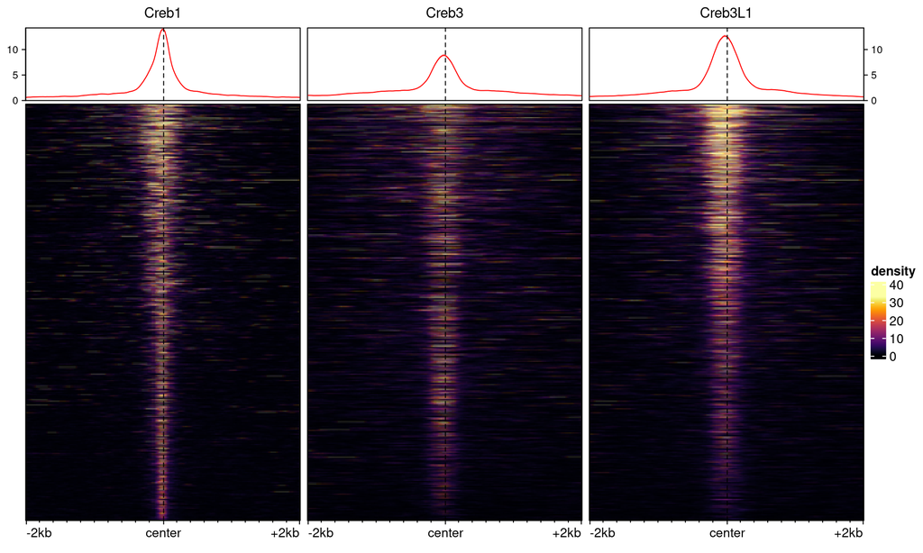

```r
plotEnrichedHeatmaps(ese)
```

The overall profiles look similar, which is expected given that these TFs belong to the same CREB family

## Clustering

### Choosing the number of clusters

We first evaluate different numbers of clusters (k = 2 to 8) using variance

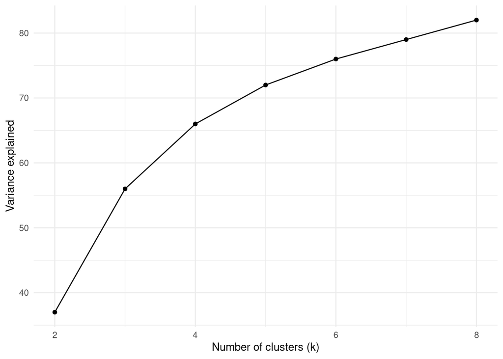

```r
set.seed(123)
cl_test <- clusterSignalMatrices(ese, k = 2:8)
ggplot(cl_test$varExplained, aes(k, varExplained)) +
  geom_line() +
  geom_point() +
  labs(x = "Number of clusters (k)", y = "Variance explained") +
  theme_minimal()
```

An elbow plot of variance shows a clear inflection around k = 4 where the curve transitions from steep gains to more modest increments, i therefore selected k = 4

### Perform clustering

```r
set.seed(123)
cl <- clusterSignalMatrices(ese, k = 4)
```

```
##   ~66% of the variance explained by clusters
```

```r
table(cl)
```

```
## cl
##   1   2   3   4
## 901 198 450 720
```

```r
# store the cluster labels in the object's row metadata
rowData(ese)$cluster <- cl
```

### Heatmap with cluster annotation

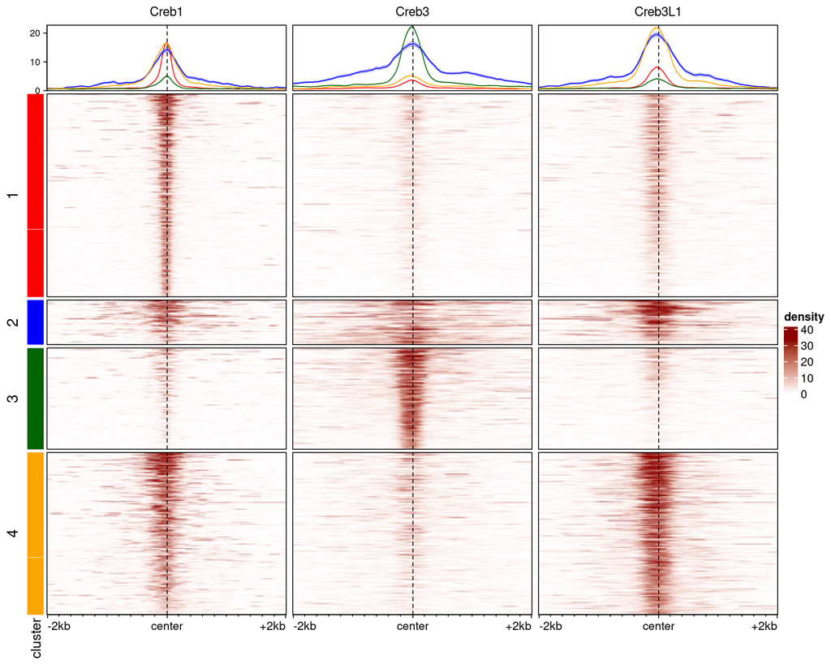

```r
mycolors <- c("1" = "red", "2" = "blue", "3" = "darkgreen", "4" = "orange")
plotEnrichedHeatmaps(ese, row_split = "cluster",
                     mean_color = mycolors,
                     colors = c("white", "darkred"))
```

Clustering with k = 4 on absolute signal reveals 4 groups of regions with clearly distinct TF occupancy profiles. Cluster 1 is dominated by strong CREB1 binding, with only weak CREB3 and a bit stronger (still weak) CREB3L1 signal. Most likely represents CREB1 specific sites. Cluster 2 contains the sites co-occupied by all three TFs at high levels, with CREB3L1 showing the highest mean signal, followed by CREB3 and CREB1. These likely represent the core shared CRE sites where all three factors compete or co-bind. Cluster 3 is characterised by strong CREB3 binding with weaker CREB1 and minimal CREB3L1 signal. These are likely CREB3-specific regulatory regions. Cluster 4 shows strong CREB3L1 binding with moderate CREB1 signal but very low CREB3 levels. These represent sites preferentially occupied by CREB1 and CREB3L1.

### Average signal profiles per cluster

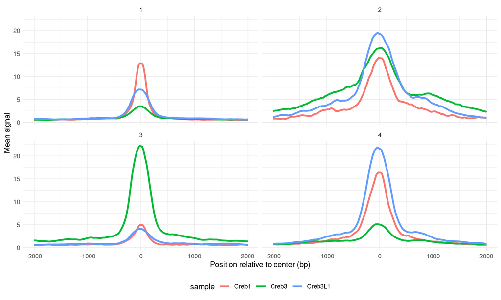

```r
d <- meltSignals(ese, splitBy = cl)
ggplot(d, aes(position, mean, colour = sample)) +
  geom_line(linewidth = 1.2) +
  facet_wrap(~split) +
  labs(x = "Position relative to center (bp)", y = "Mean signal") +
  theme_minimal() +
  theme(legend.position = "bottom")
```

cluster 1 = CREB1-dominant, cluster 2 = shared, cluster 3 = CREB3-dominant, cluster 4 = CREB3L1-dominant, co sharing with CREB1.

### Clustering on relative (scaled) signal

clustering on row-scaled signals

```r
set.seed(123)
cl_scaled <- clusterSignalMatrices(ese, k = 4, scaleRows = TRUE)
```

```
##   ~87% of the variance explained by clusters
```

```r
table(cl_scaled)
```

```
## cl_scaled
##   1   2   3   4
## 389 813 684 383
```

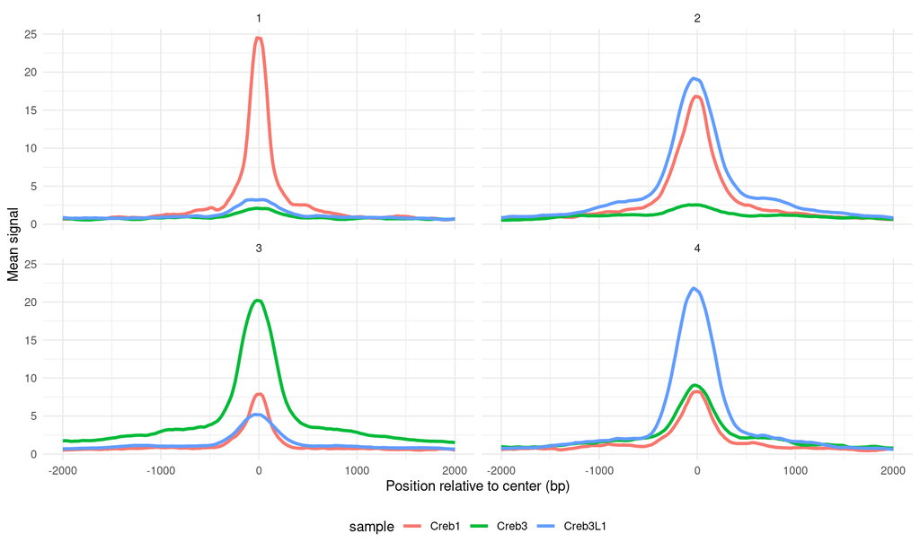

```r
d_scaled <- meltSignals(ese, splitBy = cl_scaled)
ggplot(d_scaled, aes(position, mean, colour = sample)) +
  geom_line(linewidth = 1.2) +
  facet_wrap(~split) +
  labs(x = "Position relative to center (bp)", y = "Mean signal") +
  theme_minimal() +
  theme(legend.position = "bottom")
```

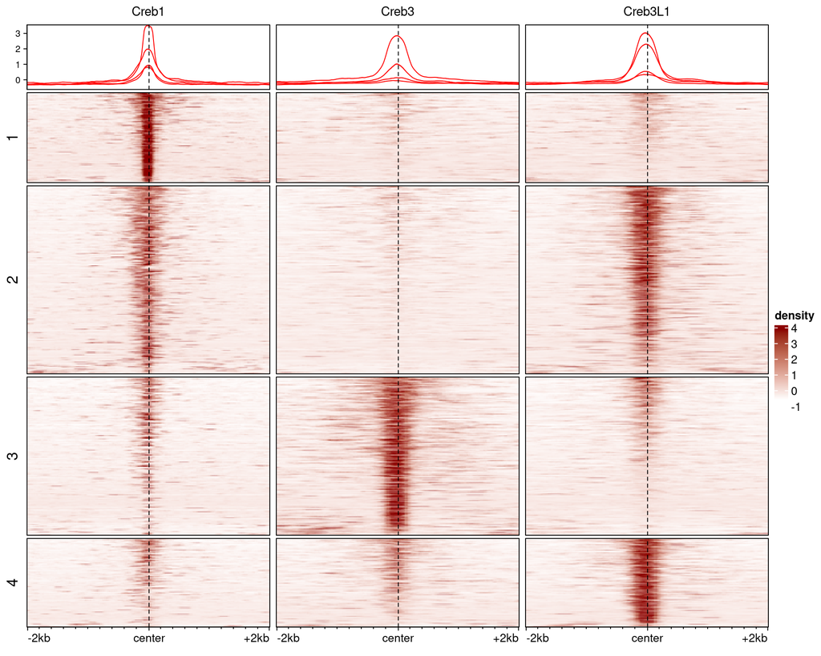

```r
plotEnrichedHeatmaps(ese, row_split = cl_scaled, scale_rows = "global",
                     colors = c("white", "darkred"))
```

## Enrichment analysis

I perform Gene Ontology for biological processes enrichment analysis using rGREAT on one of the clusters that shows a distinctive binding pattern. Using the full set of union regions as the background

```r
# split regions by cluster
split_regions <- split(rowRanges(ese), rowData(ese)$cluster)
lengths(split_regions)
```

```
##   1   2   3   4
## 901 198 450 720
```

I pick the cluster that appears most distinctive number 4:

```r
# enrichment for cluster 4
res <- great(split_regions[["4"]], gene_sets = "GO:BP",
             tss_source = "hg38",
             background = regions, cores = 2)
```

[output not shown]

[output not shown]

[output not shown]

[output not shown]

[output not shown]

[output not shown]

[output not shown]

[output not shown]

[output not shown]

[output not shown]

[output not shown]

[output not shown]

[output not shown]

[output not shown]

[output not shown]

[output not shown]

[output not shown]

[output not shown]

[output not shown]

[output not shown]

[output not shown]

[output not shown]

```r
bp <- getEnrichmentTables(res)
head(bp, 10)
```

```
##            id                                  description genome_fraction
## 1  GO:0006396                               RNA processing     0.113221886
## 2  GO:0008380                                 RNA splicing     0.056632719
## 3  GO:0006412                                  translation     0.066496070
## 4  GO:0016071                       mRNA metabolic process     0.086491200
## 5  GO:0006397                              mRNA processing     0.057120687
## 6  GO:0000387                  spliceosomal snRNP assembly     0.004631695
## 7  GO:0051053 negative regulation of DNA metabolic process     0.009592258
## 8  GO:0006282                     regulation of DNA repair     0.021769235
## 9  GO:0071826             protein-RNA complex organization     0.026654247
## 10 GO:0030166            proteoglycan biosynthetic process     0.008015473
##    observed_region_hits fold_enrichment     p_value p_adjust mean_tss_dist
## 1                   108        1.324832 0.001614125        1         38611
## 2                    58        1.422421 0.005081239        1         17058
## 3                    65        1.357641 0.008428022        1         32149
```

[output cut: 29 more lines]

### Dot plot of top enriched GO terms

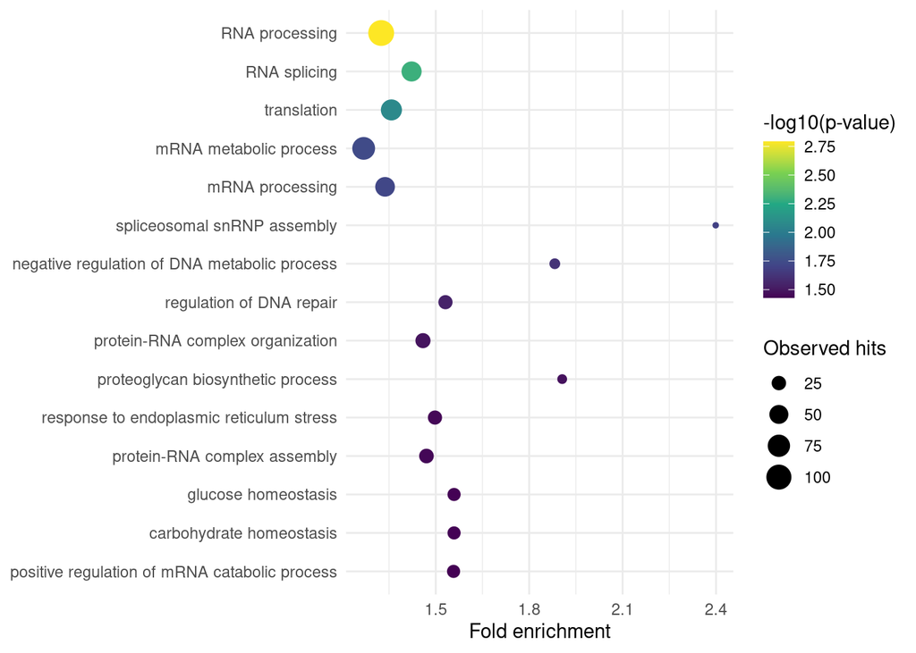

```r
ggplot(head(bp, 15), aes(fold_enrichment, reorder(description, -p_value),
                          size = observed_region_hits,
                          color = -log10(p_value))) +
  geom_point() +
  scale_color_viridis_c() +
  labs(x = "Fold enrichment", y = NULL,
       size = "Observed hits", color = "-log10(p-value)") +
  theme_minimal()
```